# Digital Access Equity in Philadelphia

Do digitally vulnerable neighbourhoods have equitable access to city internet resources?

Published

October 2, 2025

## Context

Philadelphia operates a network of free public Wi-Fi sites, a subset of which also provide public-use computers. This analysis asks whether the households least likely to have internet access and computing devices at home are within walking distance of those sites.

**Research question:** do digitally vulnerable census tracts have adequate access to free Wi-Fi sites with public computers?

## Data

**Home broadband and device access** — American Community Survey 5-year estimates, 2023 release, which covers **2019–2023**, at census-tract level for Philadelphia County. Retrieved with `tidycensus`.

| Variable | ACS code | Meaning |
| --- | --- | --- |
| `total_hh` | `B28001_001` | Total households |
| `has_broadband` | `B28002_004` | Broadband subscription of any type |
| `smartphone_only` | `B28001_006` | Smartphone with no other computing device |
| `no_computer` | `B28003_006` | No computer |
| `median_income` | `B19013_001` | Median household income |

Note that `B28003_002` is “**Has** a computer”, not its complement. The no-computer count is `B28003_006`.

This period spans the federal Affordable Connectivity Program, which subsidised home broadband for low-income households and expired in 2024. Actual broadband access today may be lower than these estimates suggest.

**Free Wi-Fi locations** — City of Philadelphia, via OpenDataPhilly (https://opendataphilly.org/datasets/free-wifi/). `scripts/00_get_data.R` downloads the layer and records the retrieval date in `data/DOWNLOAD_DATE.txt`.

All spatial data is projected to Pennsylvania South State Plane (EPSG:2272, feet) for distance work. There are 254 Wi-Fi locations and 408 Philadelphia tracts.

```r
library(sf); library(dplyr); library(ggplot2); library(stringr)
library(tigris); library(tidycensus); library(units)
library(knitr); library(ggspatial); library(ggnewscale); library(kableExtra)

options(tigris_use_cache = TRUE)
census_api_key(Sys.getenv("CENSUS_API_KEY"))

CRS_FT  <- 2272
HALF_MI <- 2640   # feet
```

```r
acs <- get_acs(
  geography = "tract",
  variables = c(total_pop = "B01003_001", total_hh = "B28001_001",
                smartphone_only = "B28001_006", has_broadband = "B28002_004",
                no_computer = "B28003_006", median_income = "B19013_001"),
  state = "PA", county = "Philadelphia", year = 2023, output = "wide"
)

# Select before joining so the join does not produce .x/.y duplicate columns.
tracts_philly <- tracts(state = "PA", cb = TRUE, year = 2023, progress_bar = FALSE) |>
  filter(COUNTYFP == "101") |>
  select(GEOID, NAMELSAD, geometry)

philly <- acs |>
  select(GEOID, total_popE, total_hhE, smartphone_onlyE,
         has_broadbandE, no_computerE, median_incomeE) |>
  left_join(tracts_philly, by = "GEOID") |>
  st_as_sf() |>
  st_transform(CRS_FT) |>
  mutate(
    percent_no_bb       = (1 - has_broadbandE / total_hhE) * 100,
    percent_smart_only  = (smartphone_onlyE   / total_hhE) * 100,
    percent_no_computer = (no_computerE       / total_hhE) * 100
  )
```

## Defining digital vulnerability

A tract is **digitally vulnerable** if it is in the top quartile of either

- households **without home broadband**, or
- households **relying on a smartphone only** for internet access.

Thresholds are computed from the data as the 75th percentile of each measure, rather than hardcoded, so they stay correct if the data is refreshed.

Smartphone-only is used deliberately here as a device-adequacy measure: a smartphone is a poor substitute for a computer for job applications, coursework and benefits enrolment. It is *not* the same as having no computer at all, and is not described as such anywhere in this document.

```r
q75 <- function(x) quantile(x, 0.75, na.rm = TRUE)
thr_bb <- q75(philly$percent_no_bb)
thr_so <- q75(philly$percent_smart_only)

vulnerable <- philly |>
  filter(percent_no_bb >= thr_bb | percent_smart_only >= thr_so) |>
  mutate(Vulnerable = "Digitally vulnerable tract")

tibble::tibble(
  Measure   = c("% households without broadband", "% households smartphone-only"),
  `75th percentile` = round(c(thr_bb, thr_so), 2)
) |> kable()
```

| Measure | 75th percentile |
| --- | --- |
| % households without broadband | 17.51 |
| % households smartphone-only | 15.77 |

## Access to Wi-Fi sites with computers

Only sites that both provide public computers **and** are currently active are counted. This single filtered object is used for every buffer, distance and map in the analysis — an earlier version filtered inconsistently between steps, which produced distances measured to the wrong sites.

```r
wifi_all <- st_read("data/free_city_wifi_locations.shp", quiet = TRUE) |>
  st_transform(CRS_FT)

wifi_computer_sites <- wifi_all |>
  filter(computers_ == "Y", to_display == "ACTIVE")

coverage <- wifi_computer_sites |> st_buffer(HALF_MI) |> st_union()

coverage_sf <- coverage |> st_cast("POLYGON") |> st_as_sf() |>
  mutate(legend = "0.5 mi from a Wi-Fi site with computers")
```

```r
tibble::tibble(
  Category = c("All free Wi-Fi locations", "With public computers",
               "With computers and active"),
  Count = c(nrow(wifi_all), sum(wifi_all$computers_ == "Y"),
            nrow(wifi_computer_sites))
) |> kable()
```

| Category | Count |
| --- | --- |
| All free Wi-Fi locations | 254 |
| With public computers | 53 |
| With computers and active | 52 |

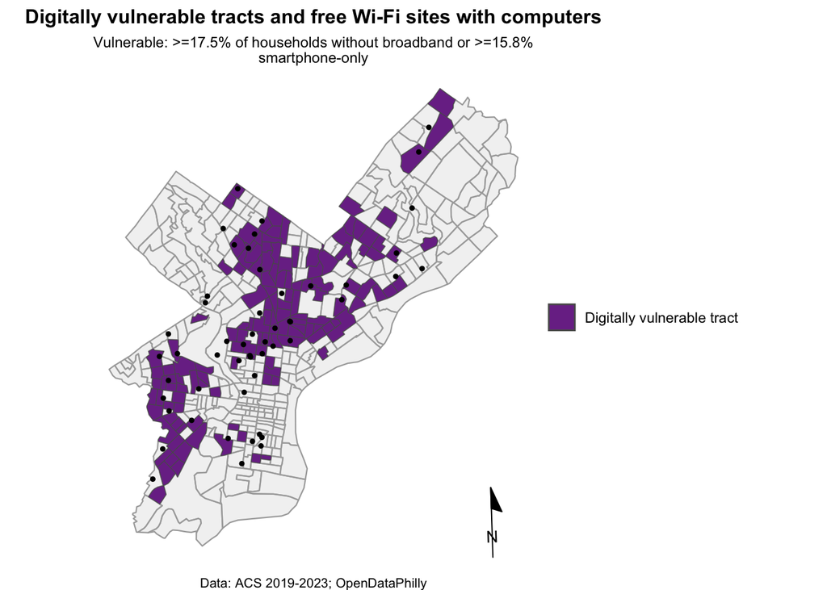

Digitally vulnerable tracts and the active free Wi-Fi sites with public computers. Data: ACS 2019–2023; OpenDataPhilly.

```r
ggplot(philly) +
  geom_sf(color = "darkgray", linewidth = 0.4, alpha = 0.5) +
  geom_sf(data = vulnerable, aes(fill = Vulnerable)) +
  scale_fill_manual(values = c("Digitally vulnerable tract" = "#7B3294"), name = NULL) +
  geom_sf(data = wifi_computer_sites, size = 0.9) +
  theme_void() +
  labs(
    title = "Digitally vulnerable tracts and free Wi-Fi sites with computers",
    subtitle = str_wrap(sprintf(
      "Vulnerable: >=%.1f%% of households without broadband or >=%.1f%% smartphone-only",
      thr_bb, thr_so), 70),
    caption = "Data: ACS 2019-2023; OpenDataPhilly"
  ) +
  annotation_north_arrow(location = "br", which_north = "true",
                         style = north_arrow_minimal) +
  theme(legend.position = "right",
        plot.title = element_text(hjust = 0.5, size = 12, face = "bold"),
        plot.subtitle = element_text(hjust = 0.5, size = 9),
        plot.caption = element_text(hjust = 0.5, size = 8))
```

## Underserved tracts

Each site with computers is buffered by half a mile — roughly a ten-minute walk — and the buffers are dissolved into one coverage polygon. A vulnerable tract is **digitally underserved** if it lies wholly outside that coverage.

```r
centroids <- st_centroid(vulnerable)

# Indices come from, and are applied to, the same filtered object.
nearest_idx <- st_nearest_feature(centroids, wifi_computer_sites)
vulnerable$dist_mi <- as.numeric(set_units(
  st_distance(centroids, wifi_computer_sites[nearest_idx, ], by_element = TRUE), "mi"))

underserved <- vulnerable[lengths(st_intersects(vulnerable, coverage)) == 0, ] |>
  mutate(
    hh_no_bb       = total_hhE - has_broadbandE,
    hh_no_computer = no_computerE,
    legend         = "Digitally underserved tract"
  )
```

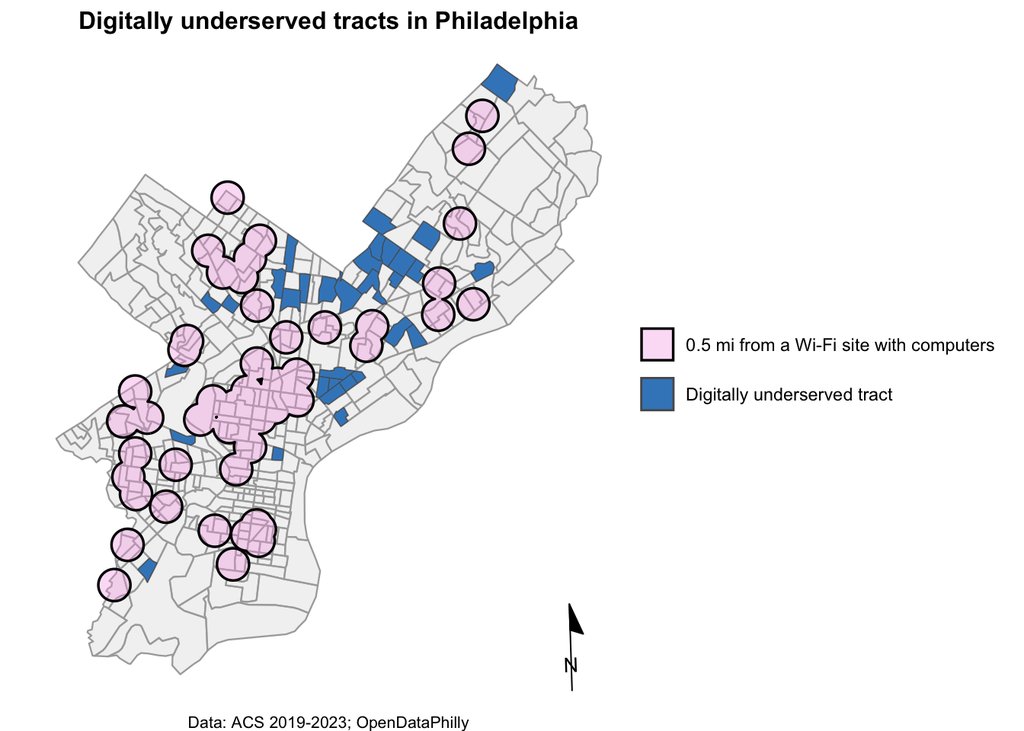

Vulnerable tracts lying wholly outside walking distance of a Wi-Fi site with computers. Data: ACS 2019–2023; OpenDataPhilly.

```r
ggplot(philly) +
  geom_sf(color = "darkgray", linewidth = 0.4, alpha = 0.5) +
  geom_sf(data = underserved, aes(fill = legend)) +
  scale_fill_manual(values = c("Digitally underserved tract" = "#3F88C5"), name = NULL) +
  new_scale_fill() +
  geom_sf(data = coverage_sf, aes(fill = legend), color = "black",
          linewidth = 0.6, alpha = 0.35) +
  scale_fill_manual(values = c("0.5 mi from a Wi-Fi site with computers" = "#F5A6E6"),
                    name = NULL) +
  theme_void() +
  labs(title = "Digitally underserved tracts in Philadelphia",
       caption = "Data: ACS 2019-2023; OpenDataPhilly") +
  annotation_north_arrow(location = "br", which_north = "true",
                         style = north_arrow_minimal) +
  theme(legend.position = "right",
        plot.title = element_text(hjust = 0.5, size = 12, face = "bold"),
        plot.caption = element_text(hjust = 0.5, size = 8))
```

## Results

```r
tibble::tibble(
  Measure = c("Vulnerable tracts", "Underserved tracts",
              "Households without broadband, underserved tracts",
              "Households with no computer, underserved tracts",
              "Mean distance to nearest site (mi)",
              "Median distance to nearest site (mi)",
              "Maximum distance to nearest site (mi)"),
  Value = c(
    format(nrow(vulnerable), big.mark = ","),
    format(nrow(underserved), big.mark = ","),
    format(sum(underserved$hh_no_bb, na.rm = TRUE), big.mark = ","),
    format(sum(underserved$hh_no_computer, na.rm = TRUE), big.mark = ","),
    sprintf("%.2f", mean(underserved$dist_mi, na.rm = TRUE)),
    sprintf("%.2f", median(underserved$dist_mi, na.rm = TRUE)),
    sprintf("%.2f", max(underserved$dist_mi, na.rm = TRUE)))
) |> kable(caption = "Headline results")
```

Headline results

| Measure | Value |
| --- | --- |
| Vulnerable tracts | 139 |
| Underserved tracts | 32 |
| Households without broadband, underserved tracts | 9,496 |
| Households with no computer, underserved tracts | 5,796 |
| Mean distance to nearest site (mi) | 1.21 |
| Median distance to nearest site (mi) | 1.11 |
| Maximum distance to nearest site (mi) | 2.52 |

The ten underserved tracts with the largest number of households without broadband. Households without broadband and households without a computer overlap heavily, so they are reported separately rather than summed — an earlier version added them together, which double-counted and was dominated by a term that counted every household that was *not* smartphone-only as being in need.

```r
underserved |>
  st_drop_geometry() |>
  arrange(desc(hh_no_bb)) |>
  head(10) |>
  select(NAMELSAD, percent_no_bb, percent_smart_only, percent_no_computer,
         hh_no_bb, hh_no_computer, median_incomeE, dist_mi) |>
  kable(
    col.names = c("Tract", "% no broadband", "% smartphone-only", "% no computer",
                  "HH no broadband", "HH no computer", "Median income",
                  "Distance to nearest site (mi)"),
    digits = 1, format.args = list(big.mark = ","), align = "lrrrrrrr",
    caption = "Ten underserved tracts with the most households without broadband"
  )
```

Ten underserved tracts with the most households without broadband

| Tract | % no broadband | % smartphone-only | % no computer | HH no broadband | HH no computer | Median income | Distance to nearest site (mi) |
| --- | --- | --- | --- | --- | --- | --- | --- |
| Census Tract 306 | 21.3 | 7.5 | 15.8 | 627 | 465 | 44,108 | 2.0 |
| Census Tract 278 | 27.3 | 37.4 | 14.4 | 618 | 325 | 33,655 | 1.0 |
| Census Tract 273 | 24.6 | 17.9 | 17.0 | 587 | 405 | 42,423 | 1.2 |
| Census Tract 282 | 24.6 | 8.6 | 22.6 | 578 | 530 | 34,420 | 1.1 |
| Census Tract 192 | 19.0 | 14.6 | 10.2 | 511 | 273 | 13,721 | 1.2 |
| Census Tract 300 | 18.2 | 14.5 | 8.0 | 500 | 219 | 33,419 | 0.8 |
| Census Tract 268 | 20.9 | 22.9 | 22.5 | 473 | 509 | 41,330 | 1.0 |
| Census Tract 122.01 | 18.8 | 19.5 | 10.7 | 391 | 222 | 42,782 | 0.7 |
| Census Tract 178 | 12.7 | 15.8 | 8.6 | 358 | 243 | 42,104 | 1.1 |
| Census Tract 298 | 18.6 | 19.6 | 8.6 | 350 | 162 | 47,292 | 1.0 |

## Limitations

- Half-mile **Euclidean** buffers ignore the street network, rivers and rail corridors; true walking distance is longer and sometimes much longer.
- Tract **centroids** are unweighted, so they may not represent where people in a tract actually live.
- ACS **margins of error** are not carried through; tracts near a threshold may be misclassified.
- Site capacity is not modelled — a site with two computers counts the same as one with thirty.
- Opening hours are not modelled; a site is treated as available at all times.